# FitHiChIP summary Report

**Parameter list for the current execution of FitHiChIP:** /public/home/xhhuang/biodate/bio_protocol/bioprotocol_github/TAD-and-loop-identification-workflows/output/FitHiChIP/Parameters.txt

**List of CIS interactions within the specified distance thresholds (lower threshold: 20000 upper threshold: 2000000 ):** /public/home/xhhuang/biodate/bio_protocol/bioprotocol_github/TAD-and-loop-identification-workflows/output/FitHiChIP/HiCPro_Matrix_BinSize5000/L_20000_U2000000/FitHiChIP.cis.interactions.DistThr.bed

Number of interacting (non zero contacts) bin pairs ( all to all ) : 196708

**Bin specific HiChIP coverage, coverage bias, and peak / non-peak boolean values:** /public/home/xhhuang/biodate/bio_protocol/bioprotocol_github/TAD-and-loop-identification-workflows/output/FitHiChIP/NormFeatures/Coverage_Bias/FitHiChIP.coverage_Bias.bed

======================================================================================

## Statistics for peak to ALL (both peak and non-peak) loops

### FitHiChIP background (0 means loose, 1 means stringent ) : 0

====================================================

### Statistics for Coverage bias regression

**All interactions with their FitHiChIP significance values:** /public/home/xhhuang/biodate/bio_protocol/bioprotocol_github/TAD-and-loop-identification-workflows/output/FitHiChIP/FitHiChIP_Peak2ALL_b5000_L20000_U2000000/P2PBckgr_0/Coverage_Bias/FitHiC_BiasCorr/FitHiChIP.interactions_FitHiC.bed

Number of interactions considered: 54952

**Significant interactions:** /public/home/xhhuang/biodate/bio_protocol/bioprotocol_github/TAD-and-loop-identification-workflows/output/FitHiChIP/FitHiChIP_Peak2ALL_b5000_L20000_U2000000/P2PBckgr_0/Coverage_Bias/FitHiC_BiasCorr/FitHiChIP.interactions_FitHiC_Q0.01.bed

Total number of significant interactions ( FDR 0.01 ) : 2105

**After merging adjacent loops (connected component modeling) significant interactions:** /public/home/xhhuang/biodate/bio_protocol/bioprotocol_github/TAD-and-loop-identification-workflows/output/FitHiChIP/FitHiChIP_Peak2ALL_b5000_L20000_U2000000/P2PBckgr_0/Coverage_Bias/FitHiC_BiasCorr/Merge_Nearby_Interactions/FitHiChIP.interactions_FitHiC_Q0.01_MergeNearContacts.bed

Total number of significant interactions ( FDR 0.01 ) after merging adjacent loops: 855

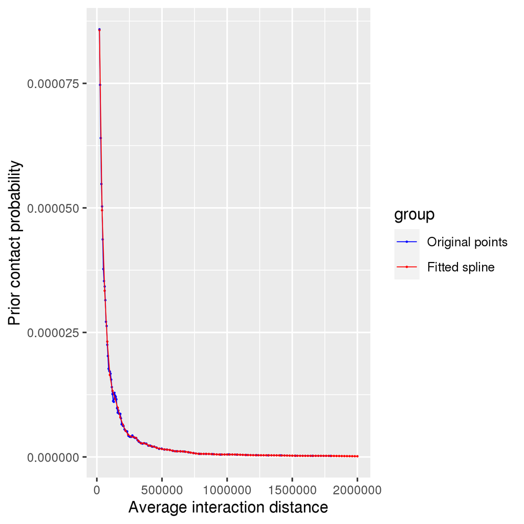

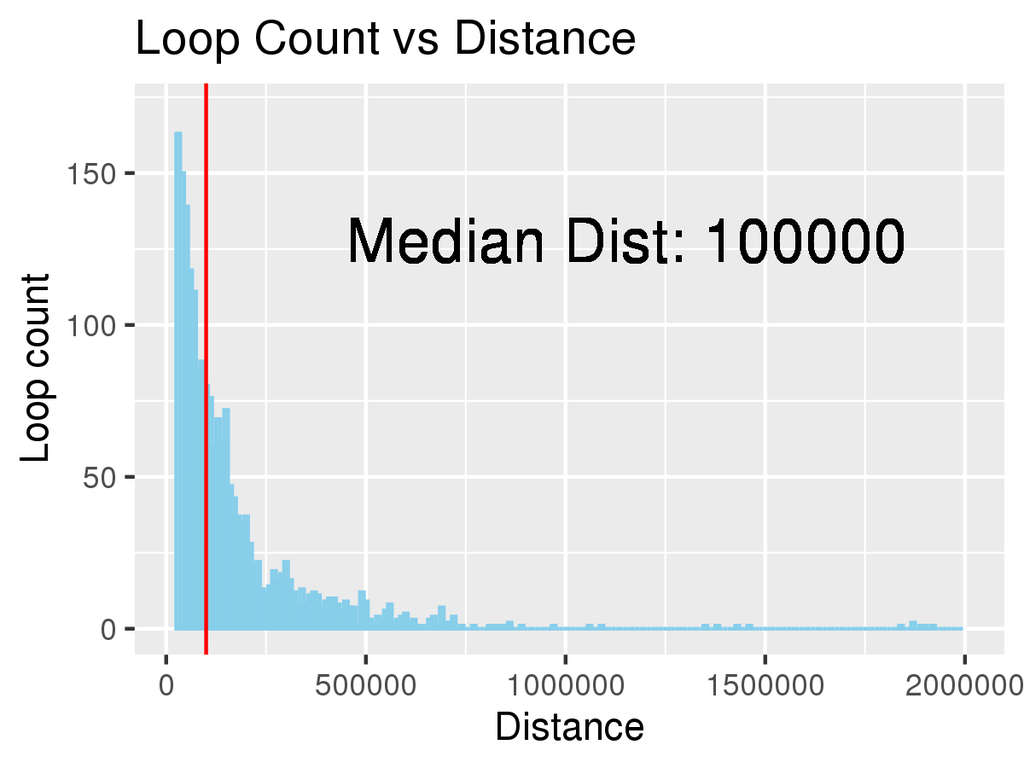

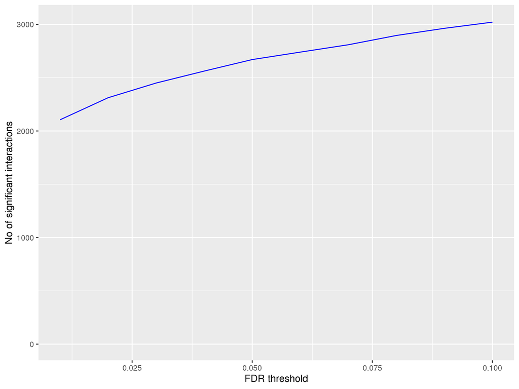

====================================================